# Tumor purity and age-matched deviation

Does tumor purity account for the deviations, pathway contributions, and clinical associations reported in the main figures?

Pan-cancer aging project

October 24, 2026

## Goal

The clocks are applied to bulk tumor RNA-seq, and a bulk tumor sample mixes malignant cells with the patient’s own stroma and immune cells. A reader will ask whether the age-matched deviations, the pathway contributions, and the clinical associations in the main figures are driven by how much tumor is in each sample rather than by tumor biology. This script answers that with the TCGA ABSOLUTE purity estimates.

Everything here reads from objects the main pipeline already saved. Nothing is recomputed and no clock is refit. Where a main-figure analysis is repeated with purity added, the model form, data filters, and contrasts follow the figure script.

**What is asked, and why**

1. *Does deviation track purity, in each of the six cancers?* If the youth-like state lives in malignant cells, deviation should become more youth-like as purity rises, because non-malignant tissue at the patient’s age sits near the age expectation and dilutes the signal. The size of the effect also says how much of the tumor-to-tumor spread purity explains.
2. *Does purity confound the deviation-survival associations?* The cross-cancer survival panel reports deviation against overall survival in each cancer. Purity could be prognostic itself, so each model is refit with purity added.
3. *In BRCA, which pathway contributions track purity?* The BRCA figures describe the pathway structure of the deviation. Purity could act through particular pathways (for example immune programs) rather than scaling everything equally.
4. *In BRCA, do the subtype, survival, and TP53 results hold with purity in the model?* These are the main-text claims that could be confounded: subtype ordering, the deviation-survival association (the forest in the survival figure), and the truncating-TP53 effect on the P53-pathway contribution, which is a purity-correlated outcome.

**What this script produces**

Four panels, each drawn in the style of the corresponding main panel so the two can be compared directly: deviation against purity in six cancers; BRCA deviation by PAM50 subtype after purity adjustment; the BRCA TP53 panel with purity in the model; and the BRCA overall-survival forest with purity in the model. One table: the cross-cancer survival models without and with purity, on the tumors with a purity value. Some panels may not appear in the published manuscript. Panels are assembled and typeset in Adobe Illustrator. The remaining tables and the pathway analysis stay in this report as the record.

**Data**

Deviations and contributions come from the saved ClockSHAP objects (`clockshap_objects-<feature_set>.rds`), exactly as used in the figures. Purity is the PanCancerAtlas ABSOLUTE estimate from the harmonized TCGA metadata, one value per patient, joined on the 12-character patient barcode. Patients with more than one tumor profile keep all profiles, each carrying the patient’s purity, so the tumor set matches the main figures. Overall survival and TP53 mutation calls come from the same files the figure scripts use. Tumors without a purity value are dropped only where purity enters a model. SCAN-B has no purity estimate, so the BRCA analyses are TCGA only.

```r
suppressPackageStartupMessages({
  library(here)
  library(dplyr)
  library(tibble)
  library(tidyr)
  library(ggplot2)
  library(survival)
  library(emmeans)
  library(ggpubr)        # stat_pvalue_manual, as in the main figure
  library(knitr)
  library(reactable)
})

msg <- function(...) if (isTRUE(params$verbose)) message(...)
```

## Cancers of interest

The six emphasis cancers, each paired with its GTEx tissue of origin.

```r
map <- list(
  BRCA = "BREAST",
  LUSC = "LUNG",
  LUAD = "LUNG",
  GBM  = "BRAIN",
  LGG  = "BRAIN",
  COAD = "COLON"
)
```

## Load purity

One row per patient; the join below relies on that.

```r
harmonized <- readRDS(params$purity_rds)

stopifnot(!anyDuplicated(harmonized$submitter_id))
stopifnot(all(nchar(harmonized$submitter_id) == 12))

purity_by_patient <- setNames(as.numeric(harmonized$purity), harmonized$submitter_id)

msg("Harmonized metadata: ", length(purity_by_patient), " patients, ",
    sum(!is.na(purity_by_patient)), " with a purity value.")
```

## Assemble the tumor table

For each cancer: read the saved ClockSHAP object and sample metadata, check that the decomposition still closes and that every tumor has metadata, bridge to the patient barcode, and attach purity. PAM50 is carried for BRCA only, and the BRCA contribution matrix is kept for the pathway analyses.

```r
suffix       <- paste0("-", params$feature_set)
out_root_abs <- here::here(params$out_root)

sample_list <- list()
phi_brca    <- NULL

for (tcga in names(map)) {
  gtex        <- map[[tcga]]
  analysis_id <- paste0(tcga, "__", gtex)
  adir        <- file.path(out_root_abs, analysis_id)

  cs   <- readRDS(file.path(adir, paste0("clockshap_objects", suffix, ".rds")))
  meta <- readRDS(file.path(adir, "sample_metadata.rds"))

  phi <- as.matrix(cs$pt$phi)
  ids <- rownames(phi)
  dev <- as.numeric(cs$pt$deviation)

  # the contributions must still sum to the deviation, and every tumor must have metadata
  stopifnot(length(dev) == nrow(phi))
  stopifnot(max(abs(rowSums(phi) - dev)) < 1e-8)
  stopifnot(all(ids %in% rownames(meta)))

  barcode <- as.character(meta[ids, "tcga.tcga_barcode"])
  patient <- substr(barcode, 1, 12)

  sample_list[[tcga]] <- tibble(
    sample_id = ids,
    cancer    = tcga,
    tissue    = gtex,
    patient   = patient,
    barcode   = barcode,
    age_years = as.numeric(meta[ids, "age_years"]),
    deviation = dev,
    purity    = unname(purity_by_patient[patient]),
    pam50     = if (tcga == "BRCA") as.character(meta[ids, "Subtype_Selected"]) else NA_character_
  )

  if (tcga == "BRCA") phi_brca <- phi

  msg(analysis_id, ": ", length(ids), " tumors, ",
      sum(!is.na(sample_list[[tcga]]$purity)), " with purity.")
}

samples <- dplyr::bind_rows(sample_list) %>%
  dplyr::mutate(cancer = factor(cancer, levels = names(map)))

# purity is a fraction; anything outside [0, 1] would mean a wrong column or join
stopifnot(all(is.na(samples$purity) | (samples$purity >= 0 & samples$purity <= 1)))
stopifnot(identical(rownames(phi_brca), samples$sample_id[samples$cancer == "BRCA"]))
```

## Load overall survival

The same clinical resource and join as the survival figures: one clinical row per patient, attached to every tumor profile of that patient. Tumors are kept where time, event, and age are available.

```r
clinical <- utils::read.csv(
  params$clinical_csv,
  na.strings       = c("NA", "", "#N/A"),
  stringsAsFactors = FALSE,
  check.names      = TRUE
)

clin2 <- clinical %>%
  dplyr::mutate(patient = substr(as.character(bcr_patient_barcode), 1, 12)) %>%
  dplyr::distinct(patient, .keep_all = TRUE) %>%
  dplyr::select(patient, OS.time, OS)

samples <- samples %>%
  dplyr::left_join(clin2, by = "patient") %>%
  dplyr::mutate(
    os_time  = suppressWarnings(as.numeric(OS.time)),
    os_event = suppressWarnings(as.numeric(OS)) == 1
  ) %>%
  dplyr::select(-OS.time, -OS)

os_eligible <- is.finite(samples$os_time) & !is.na(samples$os_event) & is.finite(samples$age_years)
msg("OS-eligible tumors: ", sum(os_eligible), " of ", nrow(samples))
```

## What was assembled

```r
assembly_summary <- samples %>%
  dplyr::group_by(cancer, tissue) %>%
  dplyr::summarise(
    tumors         = dplyr::n(),
    patients       = dplyr::n_distinct(patient),
    with_purity    = sum(!is.na(purity)),
    purity_median  = median(purity, na.rm = TRUE),
    mean_deviation = mean(deviation),
    os_eligible    = sum(is.finite(os_time) & !is.na(os_event)),
    os_events      = sum(os_event[is.finite(os_time)], na.rm = TRUE),
    .groups = "drop"
  )

knitr::kable(
  assembly_summary, digits = 2,
  caption = "Tumors assembled per cancer, with purity coverage, mean deviation, and overall-survival coverage."
)
```

Tumors assembled per cancer, with purity coverage, mean deviation, and overall-survival coverage.

| cancer | tissue | tumors | patients | with_purity | purity_median | mean_deviation | os_eligible | os_events |
| --- | --- | --- | --- | --- | --- | --- | --- | --- |
| BRCA | BREAST | 1117 | 1086 | 1069 | 0.60 | -22.94 | 1116 | 151 |
| LUSC | LUNG | 491 | 488 | 483 | 0.50 | -18.84 | 488 | 210 |
| LUAD | LUNG | 520 | 496 | 508 | 0.45 | -14.58 | 520 | 185 |
| GBM | BRAIN | 156 | 154 | 145 | 0.80 | -16.26 | 156 | 124 |
| LGG | BRAIN | 513 | 513 | 506 | 0.76 | -0.07 | 512 | 125 |
| COAD | COLON | 500 | 455 | 484 | 0.66 | -9.40 | 499 | 109 |

PAM50 coverage in BRCA, as stored in the clock metadata.

```r
knitr::kable(
  as.data.frame(table(PAM50 = samples$pam50[samples$cancer == "BRCA"], useNA = "ifany")),
  caption = "BRCA tumors by PAM50 subtype."
)
```

BRCA tumors by PAM50 subtype.

| PAM50 | Freq |
| --- | --- |
| Basal | 206 |
| Her2 | 81 |
| LumA | 573 |
| LumB | 217 |
| Normal | 40 |

```r
reactable::reactable(
  head(samples, 20) %>% dplyr::mutate(dplyr::across(where(is.numeric), ~ signif(., 4))),
  searchable = FALSE, resizable = TRUE, striped = TRUE, highlight = TRUE, defaultPageSize = 10
)
```

| sample_id | cancer | tissue | patient | barcode | age_years | deviation | purity | pam50 | os_time | os_event |
| --- | --- | --- | --- | --- | --- | --- | --- | --- | --- | --- |
| 0b1cf6de-f98f-4020-baa7-c4fc518e5f00 | BRCA | BREAST | TCGA-E9-A249 | TCGA-E9-A249-01A-11R-A169-07 | 45 | -26.57 | 0.69 | LumB | 217 | False |
| 20c90e97-e900-488e-af6a-6648d9a8bb01 | BRCA | BREAST | TCGA-BH-A1EX | TCGA-BH-A1EX-01A-11R-A13Q-07 | 67 | -11.14 | 0.64 | LumA | 1508 | True |
| 0a2fa7c7-0810-4d65-b16c-4a1792714802 | BRCA | BREAST | TCGA-AO-A12A | TCGA-AO-A12A-01A-21R-A115-07 | 47 | -12.07 | 0.41 | LumA | 3112 | False |
| cb2498a3-ade5-44a1-9df8-c611cde2ae03 | BRCA | BREAST | TCGA-AC-A3OD | TCGA-AC-A3OD-01B-06R-A22O-07 | 68 | -18.84 | 0.42 | LumA | 451 | False |
| 30f32969-5278-4066-bb82-7400cdce8807 | BRCA | BREAST | TCGA-AC-A23G | TCGA-AC-A23G-01A-11R-A213-07 | 76 | -8.06 | 0.22 | LumA | 2248 | False |
| f9e194a1-e5c1-4a1a-840b-4e0246640d09 | BRCA | BREAST | TCGA-A8-A07I | TCGA-A8-A07I-01A-11R-A00Z-07 | 69 | -21.13 | 0.71 | Her2 | 426 | False |
| 2a9ed6f1-3f93-43cf-9e47-6690781e1009 | BRCA | BREAST | TCGA-AN-A0FJ | TCGA-AN-A0FJ-01A-11R-A00Z-07 | 59 | -40.13 | 0.81 | Basal | 242 | False |
| 8f349f98-4d93-4f97-ac6b-50d2bf072b0c | BRCA | BREAST | TCGA-A7-A0CH | TCGA-A7-A0CH-01A-21R-A00Z-07 | 79 | -26.12 | 0.78 | LumA | 1079 | False |
| 46c0f948-2eac-41f7-b490-fbca1724d710 | BRCA | BREAST | TCGA-E2-A15A | TCGA-E2-A15A-01A-11R-A12D-07 | 45 | -23.96 | 0.58 | LumB | 710 | False |
| 6203b63e-6d3f-4399-b524-9573a9bd1e11 | BRCA | BREAST | TCGA-A2-A3XV | TCGA-A2-A3XV-01A-21R-A239-07 | 46 | -24.15 | 0.66 | Her2 | 996 | False |

[output cut: 10 more lines]

## The assembled object

Everything downstream reads from this one object.

```r
purity_data <- list(
  samples  = samples,     # one row per tumor across the six cancers
  phi_brca = phi_brca     # BRCA tumors x pathways, same order as samples[cancer == "BRCA", ]
)

str(purity_data, max.level = 1)
```

```
## List of 2
##  $ samples : tibble [3,297 × 11] (S3: tbl_df/tbl/data.frame)
##  $ phi_brca: num [1:1117, 1:50] 0 0 0 0 0 0 0 0 0 0 ...
##   ..- attr(*, "dimnames")=List of 2
```

## Shared helpers

```r
# Cox hazard ratio for one term; `scale` rescales the coefficient (0.1 gives HR per 10 percentage points)
cox_term <- function(df, formula_str, term_name, scale = 1) {
  fit <- survival::coxph(stats::as.formula(formula_str), data = df)
  co  <- summary(fit)$coefficients
  stopifnot(term_name %in% rownames(co))
  tibble(
    HR      = exp(scale * co[term_name, "coef"]),
    CI_low  = exp(scale * (co[term_name, "coef"] - 1.96 * co[term_name, "se(coef)"])),
    CI_high = exp(scale * (co[term_name, "coef"] + 1.96 * co[term_name, "se(coef)"])),
    p_value = co[term_name, "Pr(>|z|)"]
  )
}

# Linear-model coefficient for one term, with CI; `scale` as above
lm_term <- function(fit, term_name, scale = 1) {
  co <- summary(fit)$coefficients
  ci <- stats::confint(fit)
  stopifnot(term_name %in% rownames(co))
  tibble(
    estimate = scale * co[term_name, "Estimate"],
    CI_low   = scale * ci[term_name, 1],
    CI_high  = scale * ci[term_name, 2],
    p_value  = co[term_name, "Pr(>|t|)"]
  )
}

pam50_levels <- c("Normal-Like", "LumA", "LumB", "Her2", "Basal")
harmonize_pam50 <- function(x) {
  factor(dplyr::recode(as.character(x), "Normal" = "Normal-Like"), levels = pam50_levels)
}

# palettes shared with the main figures
pam50_pal <- c(
  "Normal-Like" = "#cccccc",
  "LumA"        = "#4575b4",
  "LumB"        = "#91bfdb",
  "Her2"        = "#fc8d59",
  "Basal"       = "#d73027"
)
hr_pal <- c(
  '"youth-like" deviation, increased risk'      = "#2c7bb6",
  'less "youth-like" deviation, increased risk' = "#d7191c"
)

theme_supp <- function(base_size = 10) {
  theme_minimal(base_size = base_size) +
    theme(
      strip.text       = element_text(face = "bold"),
      strip.background = element_rect(fill = "grey95", colour = NA)
    )
}
```

# Analysis 1 — Deviation against purity, six cancers

**Question.** Does age-matched deviation change with tumor purity, and how much of the spread among tumors does purity explain?

**Why.** If the youth-like state is carried by malignant cells, the measured deviation should scale with the malignant fraction, because non-malignant tissue at the patient’s age sits near the age expectation. A negative slope is the expected signature of that dilution. The R-squared gain says how much tumor-to-tumor variance purity accounts for beyond chronological age, which is separate from whether it explains the mean shift.

**How.** Per cancer: Spearman correlation between deviation and purity, and `deviation ~ age + purity`. The slope is reported per 10 percentage points of purity so it reads in years. `r2_purity_given_age` is the R-squared of the full model minus that of `deviation ~ age`.

```r
dev_purity <- purity_data$samples %>%
  dplyr::filter(!is.na(purity))

dev_rows <- list()

for (tcga in levels(dev_purity$cancer)) {
  d <- dplyr::filter(dev_purity, cancer == tcga)

  ct       <- suppressWarnings(stats::cor.test(d$deviation, d$purity, method = "spearman"))
  fit_age  <- stats::lm(deviation ~ age_years,          data = d)
  fit_full <- stats::lm(deviation ~ age_years + purity, data = d)
  slope    <- lm_term(fit_full, "purity", scale = 0.1)

  dev_rows[[tcga]] <- tibble(
    cancer              = tcga,
    n                   = nrow(d),
    purity_range        = sprintf("%.2f to %.2f", min(d$purity), max(d$purity)),
    spearman_rho        = unname(ct$estimate),
    spearman_p          = ct$p.value,
    slope_per_10pct     = slope$estimate,
    ci_low              = slope$CI_low,
    ci_high             = slope$CI_high,
    lm_p                = slope$p_value,
    r2_purity_given_age = summary(fit_full)$r.squared - summary(fit_age)$r.squared
  )
}

dev_purity_tbl <- dplyr::bind_rows(dev_rows) %>%
  dplyr::mutate(cancer = factor(cancer, levels = names(map)))

knitr::kable(
  dev_purity_tbl, digits = 3,
  caption = "Deviation against ABSOLUTE purity per cancer. Spearman is unadjusted; the slope and CI are from deviation ~ age + purity, per 10 percentage points of purity."
)
```

Deviation against ABSOLUTE purity per cancer. Spearman is unadjusted; the slope and CI are from deviation ~ age + purity, per 10 percentage points of purity.

| cancer | n | purity_range | spearman_rho | spearman_p | slope_per_10pct | ci_low | ci_high | lm_p | r2_purity_given_age |
| --- | --- | --- | --- | --- | --- | --- | --- | --- | --- |
| BRCA | 1069 | 0.09 to 1.00 | -0.569 | 0.000 | -2.931 | -3.205 | -2.657 | 0.000 | 0.279 |
| LUSC | 483 | 0.12 to 0.99 | -0.493 | 0.000 | -2.029 | -2.363 | -1.695 | 0.000 | 0.229 |
| LUAD | 508 | 0.09 to 1.00 | -0.397 | 0.000 | -1.791 | -2.147 | -1.436 | 0.000 | 0.160 |
| GBM | 145 | 0.18 to 1.00 | -0.590 | 0.000 | -2.614 | -3.236 | -1.993 | 0.000 | 0.313 |
| LGG | 506 | 0.17 to 1.00 | -0.201 | 0.000 | -0.853 | -1.203 | -0.504 | 0.000 | 0.041 |
| COAD | 484 | 0.17 to 1.00 | -0.154 | 0.001 | -0.557 | -0.949 | -0.165 | 0.005 | 0.014 |

Scatter per cancer with an unadjusted linear fit and the Spearman correlation in each panel. The slope and R-squared gain stay in the table above as the record. Dashed line: the GTEx age expectation (deviation of zero).

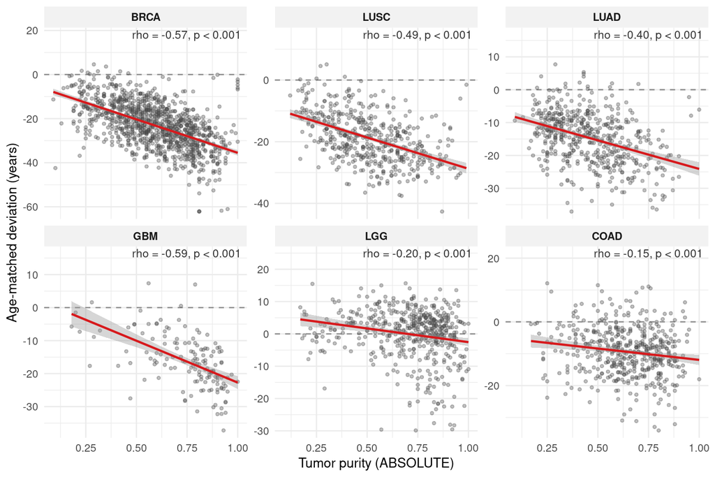

```r
dev_labels <- dev_purity_tbl %>%
  dplyr::mutate(label = sprintf("rho = %.2f, %s", spearman_rho,
                                ifelse(spearman_p < 0.001, "p < 0.001", sprintf("p = %.3f", spearman_p))))

p_dev_purity <- ggplot(dev_purity, aes(x = purity, y = deviation)) +
  geom_hline(yintercept = 0, linetype = "dashed", colour = "grey55") +
  geom_point(alpha = 0.35, size = 0.9, colour = "grey30") +
  geom_smooth(method = "lm", formula = y ~ x, se = TRUE, colour = "#d7191c", linewidth = 0.8) +
  geom_text(data = dev_labels, aes(x = Inf, y = Inf, label = label),
            hjust = 1.05, vjust = 1.3, size = 3, colour = "grey20", inherit.aes = FALSE) +
  facet_wrap(~ cancer, ncol = 3, scales = "free_y") +
  scale_y_continuous(expand = expansion(mult = c(0.05, 0.25))) +   # headroom for the annotation
  labs(x = "Tumor purity (ABSOLUTE)", y = "Age-matched deviation (years)") +
  theme_supp()

p_dev_purity
```

# Analysis 2 — Deviation and overall survival with purity, six cancers

**Question.** Do the cross-cancer deviation-survival associations change when purity is in the model, and is purity itself prognostic?

**Why.** The cross-cancer survival panel fits `Surv ~ age + deviation` per cancer. If purity predicts survival and also predicts deviation, the deviation effect could be carried by purity. Refitting with purity added, on the same tumors, tests that directly.

```r
surv_all <- purity_data$samples %>%
  dplyr::filter(is.finite(os_time), !is.na(os_event), is.finite(age_years))

surv_rows <- list()
pur_rows  <- list()

for (tcga in levels(surv_all$cancer)) {
  d_all <- dplyr::filter(surv_all, cancer == tcga)
  d_pur <- dplyr::filter(d_all, !is.na(purity))

  specs <- list(
    list(label = "age + deviation (all OS-eligible tumors)", data = d_all, f = "Surv(os_time, os_event) ~ age_years + deviation"),
    list(label = "age + deviation (tumors with purity)",     data = d_pur, f = "Surv(os_time, os_event) ~ age_years + deviation"),
    list(label = "age + deviation + purity",                 data = d_pur, f = "Surv(os_time, os_event) ~ age_years + deviation + purity")
  )

  for (s in specs) {
    surv_rows[[paste(tcga, s$label)]] <- cox_term(s$data, s$f, "deviation") %>%
      dplyr::mutate(cancer = tcga, model = s$label, n = nrow(s$data), events = sum(s$data$os_event)) %>%
      dplyr::select(cancer, model, n, events, HR, CI_low, CI_high, p_value)
  }

  pur_rows[[tcga]] <- cox_term(d_pur, "Surv(os_time, os_event) ~ age_years + deviation + purity", "purity", scale = 0.1) %>%
    dplyr::mutate(cancer = tcga, n = nrow(d_pur), events = sum(d_pur$os_event)) %>%
    dplyr::select(cancer, n, events, HR, CI_low, CI_high, p_value)
}

surv_purity_tbl <- dplyr::bind_rows(surv_rows) %>%
  dplyr::mutate(cancer = factor(cancer, levels = names(map)))

knitr::kable(
  surv_purity_tbl, digits = 4,
  caption = "Overall-survival hazard ratio per +1 year of deviation, by cancer, without and with purity in the model. Rows 2 and 3 of each cancer are fit on the same tumors."
)
```

Overall-survival hazard ratio per +1 year of deviation, by cancer, without and with purity in the model. Rows 2 and 3 of each cancer are fit on the same tumors.

| cancer | model | n | events | HR | CI_low | CI_high | p_value |
| --- | --- | --- | --- | --- | --- | --- | --- |
| BRCA | age + deviation (all OS-eligible tumors) | 1116 | 151 | 0.9839 | 0.9691 | 0.9989 | 0.0358 |
| BRCA | age + deviation (tumors with purity) | 1068 | 143 | 0.9848 | 0.9692 | 1.0006 | 0.0587 |
| BRCA | age + deviation + purity | 1068 | 143 | 0.9811 | 0.9630 | 0.9997 | 0.0459 |
| LUSC | age + deviation (all OS-eligible tumors) | 488 | 210 | 1.0127 | 0.9964 | 1.0292 | 0.1277 |
| LUSC | age + deviation (tumors with purity) | 480 | 207 | 1.0142 | 0.9978 | 1.0307 | 0.0896 |
| LUSC | age + deviation + purity | 480 | 207 | 1.0163 | 0.9979 | 1.0352 | 0.0831 |
| LUAD | age + deviation (all OS-eligible tumors) | 520 | 185 | 0.9929 | 0.9752 | 1.0110 | 0.4387 |
| LUAD | age + deviation (tumors with purity) | 508 | 176 | 0.9882 | 0.9702 | 1.0066 | 0.2074 |
| LUAD | age + deviation + purity | 508 | 176 | 0.9965 | 0.9768 | 1.0167 | 0.7339 |
| GBM | age + deviation (all OS-eligible tumors) | 156 | 124 | 1.0004 | 0.9785 | 1.0229 | 0.9699 |
| GBM | age + deviation (tumors with purity) | 145 | 115 | 0.9995 | 0.9772 | 1.0222 | 0.9634 |
| GBM | age + deviation + purity | 145 | 115 | 0.9832 | 0.9567 | 1.0105 | 0.2264 |
| LGG | age + deviation (all OS-eligible tumors) | 512 | 125 | 0.9510 | 0.9331 | 0.9693 | 0.0000 |
| LGG | age + deviation (tumors with purity) | 505 | 125 | 0.9525 | 0.9344 | 0.9709 | 0.0000 |
| LGG | age + deviation + purity | 505 | 125 | 0.9503 | 0.9320 | 0.9690 | 0.0000 |
| COAD | age + deviation (all OS-eligible tumors) | 499 | 109 | 1.0389 | 1.0126 | 1.0659 | 0.0035 |
| COAD | age + deviation (tumors with purity) | 483 | 105 | 1.0380 | 1.0113 | 1.0653 | 0.0050 |
| COAD | age + deviation + purity | 483 | 105 | 1.0384 | 1.0116 | 1.0659 | 0.0047 |

The supplementary table: one row per cancer, the deviation hazard ratio without and with purity on the tumors that have a purity value. The figure’s estimate on all OS-eligible tumors is already in the main survival table and is not repeated; it stays in the record table above.

```r
fmt_hr <- function(hr, lo, hi) sprintf("%.3f (%.3f-%.3f)", hr, lo, hi)
fmt_pv <- function(p) ifelse(p < 0.001, "<0.001", sprintf("%.3f", p))

surv_purity_si_tbl <- surv_purity_tbl %>%
  dplyr::mutate(
    column = dplyr::case_when(
      model == "age + deviation (all OS-eligible tumors)" ~ "figure",
      model == "age + deviation (tumors with purity)"     ~ "age",
      model == "age + deviation + purity"                 ~ "age_purity"
    ),
    hr_ci = fmt_hr(HR, CI_low, CI_high),
    p     = fmt_pv(p_value)
  ) %>%
  dplyr::select(cancer, column, n, events, hr_ci, p) %>%
  tidyr::pivot_wider(names_from = column, values_from = c(n, events, hr_ci, p)) %>%
  dplyr::transmute(
    Cancer                                        = cancer,
    `Tumors (events)`                             = sprintf("%d (%d)", n_age, events_age),
    `HR per year, age-adjusted (95% CI)`          = hr_ci_age,
    `p`                                           = p_age,
    `HR per year, age + purity adjusted (95% CI)` = hr_ci_age_purity,
    `p `                                          = p_age_purity
  )

knitr::kable(
  surv_purity_si_tbl,
  caption = "Supplementary table: overall-survival hazard ratio per +1 year of age-matched deviation, by cancer, on the tumors with a purity value, from the age-adjusted model and from the same model with tumor purity added."
)
```

Supplementary table: overall-survival hazard ratio per +1 year of age-matched deviation, by cancer, on the tumors with a purity value, from the age-adjusted model and from the same model with tumor purity added.

| Cancer | Tumors (events) | HR per year, age-adjusted (95% CI) | p | HR per year, age + purity adjusted (95% CI) | p |
| --- | --- | --- | --- | --- | --- |
| BRCA | 1068 (143) | 0.985 (0.969-1.001) | 0.059 | 0.981 (0.963-1.000) | 0.046 |
| LUSC | 480 (207) | 1.014 (0.998-1.031) | 0.090 | 1.016 (0.998-1.035) | 0.083 |
| LUAD | 508 (176) | 0.988 (0.970-1.007) | 0.207 | 0.997 (0.977-1.017) | 0.734 |
| GBM | 145 (115) | 0.999 (0.977-1.022) | 0.963 | 0.983 (0.957-1.011) | 0.226 |
| LGG | 505 (125) | 0.952 (0.934-0.971) | <0.001 | 0.950 (0.932-0.969) | <0.001 |
| COAD | 483 (105) | 1.038 (1.011-1.065) | 0.005 | 1.038 (1.012-1.066) | 0.005 |

# BRCA — tumor table for the breast analyses

BRCA tumors with PAM50 relabelled as in the figures (“Normal” to “Normal-Like”). Purity may be missing; each analysis below filters as it needs.

```r
brca <- purity_data$samples %>%
  dplyr::filter(cancer == "BRCA") %>%
  dplyr::mutate(pam50 = harmonize_pam50(pam50))

stopifnot(!anyNA(brca$pam50))
stopifnot(identical(rownames(purity_data$phi_brca), brca$sample_id))

brca_pur <- dplyr::filter(brca, !is.na(purity))
phi_b    <- purity_data$phi_brca[brca_pur$sample_id, , drop = FALSE]
retained <- colnames(phi_b)[colSums(abs(phi_b)) > 0]

msg("BRCA tumors: ", nrow(brca), "; with purity: ", nrow(brca_pur),
    "; retained pathways: ", length(retained))
```

# Analysis 3 — BRCA pathway contributions against purity

Kept in this report as the record (not used in the manuscript).

**Question.** Which pathway contributions track purity in BRCA, and are they the same pathways that carry the mean youth-like shift?

**Why.** Purity could scale every contribution equally, or it could act through particular programs. Immune and stromal Hallmark sets are expected to depend on how much non-malignant tissue is in the sample; proliferative programs are not. Comparing each pathway’s cohort-mean contribution with its purity dependence separates the two roles. PAM50 is the dominant source of variation in BRCA, so each correlation is also computed within subtype.

**How.** BRCA tumors with purity, and the pathways the breast clock retained (non-zero column). For each pathway: Spearman correlation between its contribution and purity, raw, and the partial Spearman correlation after regressing both the contribution and purity on PAM50. Total deviation is included as a reference row. Benjamini-Hochberg adjustment is over the pathways only.

```r
partial_spearman <- function(x, y, z) {
  rx <- stats::residuals(stats::lm(x ~ z))
  ry <- stats::residuals(stats::lm(y ~ z))
  ct <- suppressWarnings(stats::cor.test(rx, ry, method = "spearman"))
  c(rho = unname(ct$estimate), p = ct$p.value)
}

path_rows <- list()

for (pw in c("Total deviation", retained)) {
  v   <- if (pw == "Total deviation") brca_pur$deviation else phi_b[, pw]
  raw <- suppressWarnings(stats::cor.test(v, brca_pur$purity, method = "spearman"))
  adj <- partial_spearman(v, brca_pur$purity, brca_pur$pam50)

  path_rows[[pw]] <- tibble(
    pathway       = pw,
    mean_phi      = mean(v),
    rho_raw       = unname(raw$estimate),
    p_raw         = raw$p.value,
    rho_pam50_adj = adj[["rho"]],
    p_pam50_adj   = adj[["p"]]
  )
}

phi_purity_tbl <- dplyr::bind_rows(path_rows)

is_pw <- phi_purity_tbl$pathway != "Total deviation"
phi_purity_tbl$p_raw_bh       <- NA_real_
phi_purity_tbl$p_pam50_adj_bh <- NA_real_
phi_purity_tbl$p_raw_bh[is_pw]       <- stats::p.adjust(phi_purity_tbl$p_raw[is_pw],       method = "BH")
phi_purity_tbl$p_pam50_adj_bh[is_pw] <- stats::p.adjust(phi_purity_tbl$p_pam50_adj[is_pw], method = "BH")

phi_purity_tbl <- phi_purity_tbl %>%
  dplyr::arrange(pathway != "Total deviation", dplyr::desc(abs(rho_raw)))

knitr::kable(
  phi_purity_tbl, digits = 3,
  caption = "BRCA pathway contributions against purity. rho_raw is the Spearman correlation; rho_pam50_adj is the partial Spearman correlation after regressing both variables on PAM50. BH adjustment is over the retained pathways."
)
```

BRCA pathway contributions against purity. rho_raw is the Spearman correlation; rho_pam50_adj is the partial Spearman correlation after regressing both variables on PAM50. BH adjustment is over the retained pathways.

| pathway | mean_phi | rho_raw | p_raw | rho_pam50_adj | p_pam50_adj | p_raw_bh | p_pam50_adj_bh |
| --- | --- | --- | --- | --- | --- | --- | --- |
| Total deviation | -23.062 | -0.569 | 0.000 | -0.616 | 0.000 | NA | NA |
| Il2 Stat5 Signaling | -1.462 | -0.681 | 0.000 | -0.665 | 0.000 | 0.000 | 0.000 |
| Complement | -0.238 | -0.660 | 0.000 | -0.640 | 0.000 | 0.000 | 0.000 |
| Apoptosis | -0.014 | -0.609 | 0.000 | -0.608 | 0.000 | 0.000 | 0.000 |
| Coagulation | -0.466 | -0.583 | 0.000 | -0.570 | 0.000 | 0.000 | 0.000 |
| Tnfa Signaling Via Nfkb | -1.995 | -0.580 | 0.000 | -0.559 | 0.000 | 0.000 | 0.000 |
| P53 Pathway | -3.000 | -0.483 | 0.000 | -0.447 | 0.000 | 0.000 | 0.000 |
| Hypoxia | -1.130 | -0.470 | 0.000 | -0.423 | 0.000 | 0.000 | 0.000 |
| Myogenesis | -4.777 | -0.445 | 0.000 | -0.434 | 0.000 | 0.000 | 0.000 |
| Reactive Oxygen Species Pathway | -0.186 | -0.347 | 0.000 | -0.317 | 0.000 | 0.000 | 0.000 |
| Spermatogenesis | -0.140 | -0.304 | 0.000 | -0.377 | 0.000 | 0.000 | 0.000 |
| Wnt Beta Catenin Signaling | 2.474 | 0.283 | 0.000 | 0.252 | 0.000 | 0.000 | 0.000 |
| Hedgehog Signaling | -0.518 | -0.261 | 0.000 | -0.220 | 0.000 | 0.000 | 0.000 |
| Uv Response Up | -0.371 | 0.219 | 0.000 | 0.215 | 0.000 | 0.000 | 0.000 |
| Kras Signaling Dn | 0.151 | 0.151 | 0.000 | 0.097 | 0.001 | 0.000 | 0.002 |
| G2m Checkpoint | -7.449 | -0.107 | 0.000 | -0.134 | 0.000 | 0.001 | 0.000 |
| Pancreas Beta Cells | 0.082 | 0.062 | 0.043 | 0.079 | 0.010 | 0.049 | 0.011 |
| Glycolysis | -6.358 | 0.025 | 0.419 | -0.019 | 0.525 | 0.444 | 0.525 |
| Unfolded Protein Response | 2.334 | -0.017 | 0.574 | -0.032 | 0.292 | 0.574 | 0.309 |

## Overview: mean contribution beside purity correlation

Each retained pathway’s mean contribution beside its purity correlation, in the same order. A pathway with a large mean and near-zero correlation carries the cohort shift regardless of purity; a pathway with a near-zero mean and a large correlation moves individual tumors with purity but averages out.

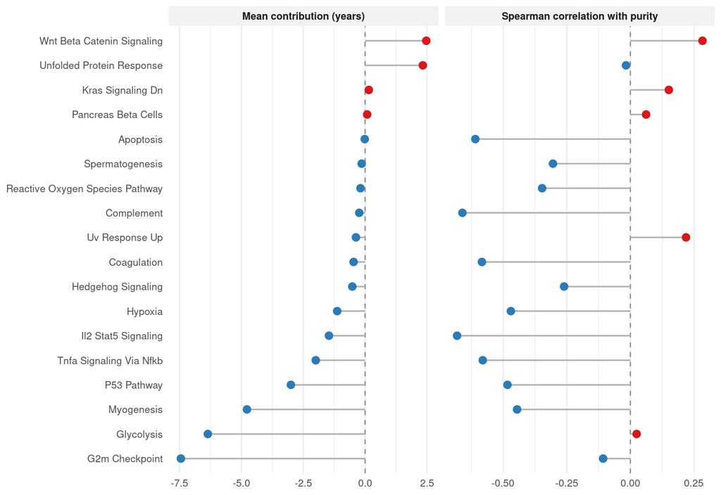

```r
phi_plot_df <- phi_purity_tbl %>%
  dplyr::filter(pathway != "Total deviation") %>%
  dplyr::mutate(pathway = factor(pathway, levels = pathway[order(mean_phi)])) %>%
  dplyr::select(pathway, `Mean contribution (years)` = mean_phi, `Spearman correlation with purity` = rho_raw) %>%
  tidyr::pivot_longer(-pathway, names_to = "metric", values_to = "value") %>%
  dplyr::mutate(metric = factor(metric, levels = c("Mean contribution (years)", "Spearman correlation with purity")))

p_phi_purity <- ggplot(phi_plot_df, aes(x = value, y = pathway)) +
  geom_vline(xintercept = 0, linetype = "dashed", colour = "grey55") +
  geom_segment(aes(x = 0, xend = value, yend = pathway), colour = "grey70", linewidth = 0.6) +
  geom_point(aes(colour = value < 0), size = 2.6) +
  scale_colour_manual(values = c("TRUE" = "#2c7bb6", "FALSE" = "#d7191c"), guide = "none") +
  facet_wrap(~ metric, scales = "free_x") +
  labs(x = NULL, y = NULL) +
  theme_supp() +
  theme(panel.grid.major.y = element_blank())

p_phi_purity
```

## Pathways of interest: contribution against purity, per tumor

The six pathways the BRCA figures discuss (G2M checkpoint, glycolysis, myogenesis, P53 pathway, Wnt/β-catenin, unfolded protein response) and three immune or stromal pathways with the strongest purity dependence. One point per tumor, coloured by PAM50, with an unadjusted linear fit and the Spearman correlation in each panel title. Dashed line: the age expectation (contribution of zero).

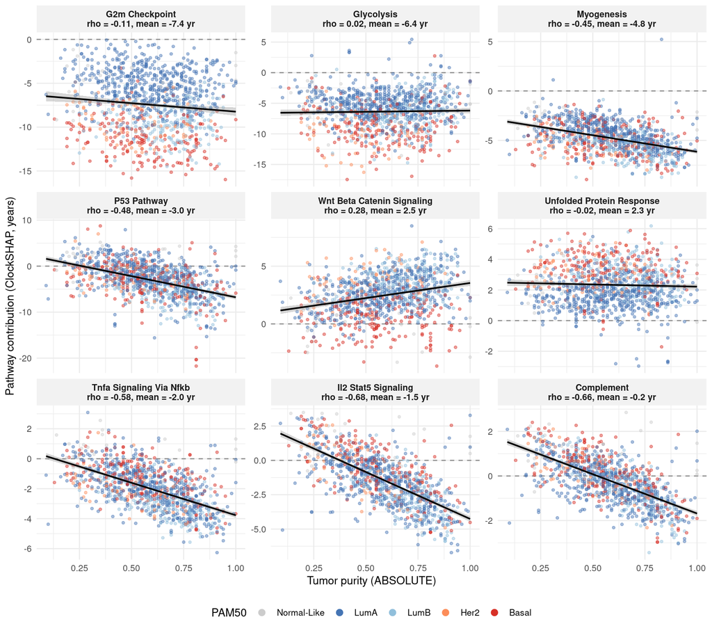

```r
poi <- intersect(params$poi_pathways, colnames(phi_b))
if (length(poi) < length(params$poi_pathways)) {
  msg("Pathways of interest not found in the contribution matrix: ",
      paste(setdiff(params$poi_pathways, colnames(phi_b)), collapse = ", "))
}

poi_long <- as.data.frame(phi_b[, poi, drop = FALSE]) %>%
  tibble::rownames_to_column("sample_id") %>%
  tidyr::pivot_longer(-sample_id, names_to = "pathway", values_to = "phi") %>%
  dplyr::left_join(brca_pur %>% dplyr::select(sample_id, purity, pam50), by = "sample_id")

poi_labels <- phi_purity_tbl %>%
  dplyr::filter(pathway %in% poi) %>%
  dplyr::mutate(label = sprintf("%s\nrho = %.2f, mean = %.1f yr", pathway, rho_raw, mean_phi)) %>%
  dplyr::select(pathway, label)

poi_long <- poi_long %>%
  dplyr::left_join(poi_labels, by = "pathway") %>%
  dplyr::mutate(label = factor(label, levels = poi_labels$label[match(poi, poi_labels$pathway)]))

p_poi_purity <- ggplot(poi_long, aes(x = purity, y = phi)) +
  geom_hline(yintercept = 0, linetype = "dashed", colour = "grey55") +
  geom_point(aes(colour = pam50), alpha = 0.45, size = 0.9) +
  geom_smooth(method = "lm", formula = y ~ x, se = TRUE, colour = "black", linewidth = 0.7) +
  scale_colour_manual(values = pam50_pal, name = "PAM50") +
  facet_wrap(~ label, ncol = 3, scales = "free_y") +
  labs(x = "Tumor purity (ABSOLUTE)", y = "Pathway contribution (ClockSHAP, years)") +
  theme_supp() +
  theme(legend.position = "bottom") +
  guides(colour = guide_legend(override.aes = list(alpha = 1, size = 2.5)))

p_poi_purity
```

# Analysis 4 — BRCA main-text claims with purity in the model

## 4a. Subtype ordering

**Question.** Does the PAM50 ordering of deviation hold once purity is accounted for?

**Why.** Subtypes differ in purity (Normal-Like lowest), so part of the subtype spread in deviation could be composition. If purity were behind the subtype effect, adding it would absorb that effect.

**How.** `deviation ~ PAM50 + age` and `deviation ~ PAM50 + age + purity` on tumors with purity. Adjusted means are predictions per subtype at the cohort mean age and, in the second model, the cohort mean purity. The PAM50 partial F in each model shows whether the subtype effect shrinks or grows when purity is added.

```r
fit_sub   <- stats::lm(deviation ~ pam50 + age_years,          data = brca_pur)
fit_sub_p <- stats::lm(deviation ~ pam50 + age_years + purity, data = brca_pur)

newdat <- tibble(
  pam50     = factor(pam50_levels, levels = pam50_levels),
  age_years = mean(brca_pur$age_years),
  purity    = mean(brca_pur$purity)
)
adj_mean <- function(fit) as.numeric(stats::predict(fit, newdata = newdat))

subtype_tbl <- tibble(
  pam50                = pam50_levels,
  n                    = as.integer(table(brca_pur$pam50)[pam50_levels]),
  mean_purity          = as.numeric(tapply(brca_pur$purity,    brca_pur$pam50, mean)[pam50_levels]),
  raw_mean_deviation   = as.numeric(tapply(brca_pur$deviation, brca_pur$pam50, mean)[pam50_levels]),
  age_adjusted         = adj_mean(fit_sub),
  age_purity_adjusted  = adj_mean(fit_sub_p)
)

knitr::kable(
  subtype_tbl, digits = 2,
  caption = "Mean deviation by PAM50 subtype: raw, adjusted for age, and adjusted for age and purity."
)
```

Mean deviation by PAM50 subtype: raw, adjusted for age, and adjusted for age and purity.

| pam50 | n | mean_purity | raw_mean_deviation | age_adjusted | age_purity_adjusted |
| --- | --- | --- | --- | --- | --- |
| Normal-Like | 33 | 0.47 | -9.90 | -10.77 | -13.85 |
| LumA | 552 | 0.59 | -18.96 | -18.74 | -18.92 |
| LumB | 212 | 0.67 | -29.79 | -29.67 | -27.55 |
| Her2 | 79 | 0.50 | -24.75 | -24.84 | -27.19 |
| Basal | 193 | 0.57 | -28.97 | -29.53 | -29.87 |

```r
pur_slope <- lm_term(fit_sub_p, "purity", scale = 0.1)
an_s  <- stats::anova(fit_sub)
an_sp <- stats::anova(fit_sub_p)

subtype_model_tbl <- tibble(
  quantity = c(
    "Purity slope per 10 pct (years), age + PAM50 adjusted",
    "Purity p-value",
    "PAM50 partial F, without purity",
    "PAM50 partial F, with purity",
    "R-squared, age + PAM50",
    "R-squared, age + PAM50 + purity"
  ),
  value = c(
    pur_slope$estimate,
    pur_slope$p_value,
    an_s["pam50", "F value"],
    an_sp["pam50", "F value"],
    summary(fit_sub)$r.squared,
    summary(fit_sub_p)$r.squared
  )
)

knitr::kable(subtype_model_tbl, digits = 4, caption = "Model terms for the two subtype models.")
```

Model terms for the two subtype models.

| quantity | value |
| --- | --- |
| Purity slope per 10 pct (years), age + PAM50 adjusted | -2.7145 |
| Purity p-value | 0.0000 |
| PAM50 partial F, without purity | 111.8754 |
| PAM50 partial F, with purity | 168.8096 |
| R-squared, age + PAM50 | 0.3371 |
| R-squared, age + PAM50 + purity | 0.5611 |

Age-matched deviation by PAM50 subtype after purity adjustment, drawn as in the main subtype panel. Each tumor’s deviation is adjusted to the cohort mean purity using the purity slope from `deviation ~ PAM50 + age + purity`, which leaves the subtype and age structure untouched and removes only the purity component. Adjacent normal has no purity estimate and is not shown. Subtypes compared by Kruskal-Wallis on the adjusted values, as in the main panel.

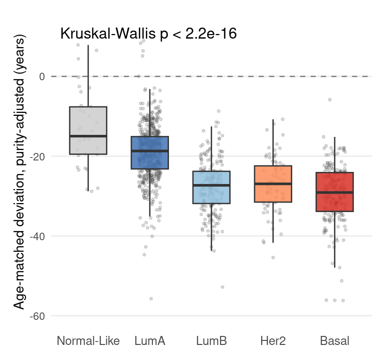

```r
purity_beta <- stats::coef(fit_sub_p)[["purity"]]

brca_adj <- brca_pur %>%
  dplyr::mutate(deviation_adj = deviation - purity_beta * (purity - mean(purity)))

kw_adj <- suppressWarnings(stats::kruskal.test(deviation_adj ~ pam50, data = brca_adj))
fmt_p  <- function(p) if (p < 2.2e-16) "p < 2.2e-16" else paste0("p = ", formatC(p, format = "e", digits = 2))

y_lab_pos <- max(brca_adj$deviation_adj) + 0.05 * diff(range(brca_adj$deviation_adj))

p_subtype_adj <- ggplot(brca_adj, aes(x = pam50, y = deviation_adj, fill = pam50)) +
  geom_hline(yintercept = 0, linetype = "dashed", colour = "grey50") +
  geom_jitter(width = 0.18, alpha = 0.18, size = 0.7, colour = "grey25") +
  geom_boxplot(width = 0.6, outlier.shape = NA, alpha = 0.85) +
  scale_fill_manual(values = pam50_pal, guide = "none") +
  coord_cartesian(ylim = c(-60, NA)) +
  annotate("text", x = -Inf, y = y_lab_pos, label = paste("Kruskal-Wallis", fmt_p(kw_adj$p.value)),
           hjust = -0.05, vjust = 1, size = 4) +
  labs(x = NULL, y = "Age-matched deviation, purity-adjusted (years)") +
  theme_minimal(base_size = 10) +
  theme(
    panel.grid.minor   = element_blank(),
    panel.grid.major.x = element_blank(),
    axis.title.y       = element_text(size = 10),
    axis.text.x        = element_text(size = 9),
    axis.text.y        = element_text(size = 8),
    plot.margin        = margin(10, 10, 10, 10)
  )

p_subtype_adj
```

## 4b. Overall survival: the figure’s Cox forest with purity added

**Question.** Does any row of the BRCA survival forest change when purity is added?

**Why.** The survival figure reports the aggregate deviation-survival association, its attenuation under PAM50 adjustment, and the within-subtype estimates. Each is a claim that purity could confound.

**How.** The figure’s row set and models, TCGA only: `Surv ~ age + deviation` on all tumors, the same with PAM50, and the same within each subtype (a subtype is fit when it has at least 5 tumors and 2 events, as in the figure). Every row is fit twice on the tumors with purity: as in the figure, and with purity added. The forest uses the figure’s colour (HR direction) and shape (p below 0.05) conventions. The all-tumor row on the full cohort, without the purity filter, is the first BRCA row of Analysis 2.

```r
surv_brca_pur <- dplyr::filter(brca_pur, is.finite(os_time), !is.na(os_event), is.finite(age_years))

msg("OS-eligible BRCA tumors with purity: ", nrow(surv_brca_pur), " (", sum(surv_brca_pur$os_event), " events).")

run_forest_rows <- function(df, with_purity) {
  add <- if (with_purity) " + purity" else ""
  rows <- list()

  rows[["all"]] <- cox_term(df, paste0("Surv(os_time, os_event) ~ age_years + deviation", add), "deviation") %>%
    dplyr::mutate(model = "All tumors", n = nrow(df), events = sum(df$os_event))

  rows[["pam50"]] <- cox_term(df, paste0("Surv(os_time, os_event) ~ age_years + deviation + pam50", add), "deviation") %>%
    dplyr::mutate(model = "All tumors (PAM50-adjusted)", n = nrow(df), events = sum(df$os_event))

  for (s in pam50_levels) {
    d <- dplyr::filter(df, pam50 == s)
    if (nrow(d) < 5 || sum(d$os_event) < 2) next
    rows[[s]] <- cox_term(d, paste0("Surv(os_time, os_event) ~ age_years + deviation", add), "deviation") %>%
      dplyr::mutate(model = paste("Subtype:", s), n = nrow(d), events = sum(d$os_event))
  }

  dplyr::bind_rows(rows) %>%
    dplyr::mutate(adjustment = if (with_purity) "Age + purity adjusted" else "Age adjusted (as in figure)") %>%
    dplyr::select(adjustment, model, n, events, HR, CI_low, CI_high, p_value)
}

brca_forest_tbl <- dplyr::bind_rows(
  run_forest_rows(surv_brca_pur, with_purity = FALSE),
  run_forest_rows(surv_brca_pur, with_purity = TRUE)
)

knitr::kable(
  brca_forest_tbl, digits = 4,
  caption = "BRCA overall-survival forest rows (TCGA, tumors with purity): hazard ratio per +1 year of deviation, as in the figure and with purity added."
)
```

BRCA overall-survival forest rows (TCGA, tumors with purity): hazard ratio per +1 year of deviation, as in the figure and with purity added.

| adjustment | model | n | events | HR | CI_low | CI_high | p_value |
| --- | --- | --- | --- | --- | --- | --- | --- |
| Age adjusted (as in figure) | All tumors | 1068 | 143 | 0.9848 | 0.9692 | 1.0006 | 0.0587 |
| Age adjusted (as in figure) | All tumors (PAM50-adjusted) | 1068 | 143 | 0.9926 | 0.9737 | 1.0119 | 0.4518 |
| Age adjusted (as in figure) | Subtype: Normal-Like | 33 | 6 | 0.9771 | 0.8839 | 1.0802 | 0.6509 |
| Age adjusted (as in figure) | Subtype: LumA | 551 | 59 | 0.9833 | 0.9561 | 1.0112 | 0.2376 |
| Age adjusted (as in figure) | Subtype: LumB | 212 | 34 | 0.9939 | 0.9539 | 1.0356 | 0.7710 |
| Age adjusted (as in figure) | Subtype: Her2 | 79 | 16 | 1.0292 | 0.9559 | 1.1081 | 0.4457 |
| Age adjusted (as in figure) | Subtype: Basal | 193 | 28 | 1.0151 | 0.9727 | 1.0592 | 0.4918 |
| Age + purity adjusted | All tumors | 1068 | 143 | 0.9811 | 0.9630 | 0.9997 | 0.0459 |
| Age + purity adjusted | All tumors (PAM50-adjusted) | 1068 | 143 | 0.9960 | 0.9725 | 1.0200 | 0.7399 |
| Age + purity adjusted | Subtype: Normal-Like | 33 | 6 | 0.9181 | 0.7968 | 1.0578 | 0.2371 |
| Age + purity adjusted | Subtype: LumA | 551 | 59 | 0.9708 | 0.9381 | 1.0046 | 0.0894 |
| Age + purity adjusted | Subtype: LumB | 212 | 34 | 1.0188 | 0.9599 | 1.0812 | 0.5402 |
| Age + purity adjusted | Subtype: Her2 | 79 | 16 | 1.0861 | 0.9930 | 1.1879 | 0.0708 |
| Age + purity adjusted | Subtype: Basal | 193 | 28 | 1.0351 | 0.9797 | 1.0937 | 0.2191 |

The comparison table above is the record. The panel below shows the purity-adjusted rows alone, drawn as the TCGA-BRCA half of the main survival forest; the unadjusted rows are the main panel.

[figure not shown]

```r
forest_df <- brca_forest_tbl %>%
  dplyr::filter(adjustment == "Age + purity adjusted") %>%
  dplyr::mutate(
    model  = factor(model, levels = rev(unique(model))),
    sig    = ifelse(p_value < 0.05, "p < 0.05", "p ≥ 0.05"),
    hr_dir = factor(
      ifelse(HR < 1, '"youth-like" deviation, increased risk', 'less "youth-like" deviation, increased risk'),
      levels = names(hr_pal)
    ),
    cohort = "TCGA-BRCA (OS), age + purity adjusted"
  )

p_brca_forest <- ggplot(forest_df, aes(x = HR, y = model, colour = hr_dir)) +
  geom_errorbarh(aes(xmin = CI_low, xmax = CI_high), height = 0.2, linewidth = 0.55) +
  geom_point(aes(shape = sig), size = 2.6) +
  geom_vline(xintercept = 1, linetype = "dashed", colour = "grey55") +
  scale_x_log10() +
  scale_shape_manual(values = c("p < 0.05" = 19, "p ≥ 0.05" = 1), name = NULL, drop = FALSE) +
  scale_colour_manual(values = hr_pal, name = NULL, drop = FALSE) +
  facet_wrap(~ cohort, ncol = 1) +
  labs(x = "HR per +1 yr of Deviation, age + purity adjusted (log scale)", y = NULL) +
  theme_minimal(base_size = 9) +
  theme(
    strip.text         = element_text(face = "bold", size = 9),
    strip.background   = element_rect(fill = "grey95", colour = NA),
    panel.grid.major.y = element_blank(),
    legend.position    = "bottom",
    legend.box         = "vertical",
    legend.spacing.y   = unit(1, "pt"),
    legend.margin      = margin(0, 0, 0, 0),
    legend.text        = element_text(size = 8),
    axis.text          = element_text(size = 8),
    axis.title         = element_text(size = 9),
    plot.margin        = margin(4, 4, 4, 4)
  )

p_brca_forest
```

Purity’s own hazard ratio in the two aggregate models that include it.

```r
brca_cox_pur_tbl <- dplyr::bind_rows(
  cox_term(surv_brca_pur, "Surv(os_time, os_event) ~ age_years + deviation + purity",         "purity", scale = 0.1) %>%
    dplyr::mutate(model = "All tumors"),
  cox_term(surv_brca_pur, "Surv(os_time, os_event) ~ age_years + deviation + pam50 + purity", "purity", scale = 0.1) %>%
    dplyr::mutate(model = "All tumors (PAM50-adjusted)")
) %>%
  dplyr::select(model, HR, CI_low, CI_high, p_value)

knitr::kable(
  brca_cox_pur_tbl, digits = 4,
  caption = "Purity's own BRCA overall-survival hazard ratio per +10 percentage points."
)
```

Purity’s own BRCA overall-survival hazard ratio per +10 percentage points.

| model | HR | CI_low | CI_high | p_value |
| --- | --- | --- | --- | --- |
| All tumors | 0.9627 | 0.8701 | 1.0650 | 0.4605 |
| All tumors (PAM50-adjusted) | 1.0262 | 0.9196 | 1.1453 | 0.6437 |

## 4c. Truncating TP53 and the P53-pathway contribution

**Question.** Does the association between truncating TP53 mutations and a more youth-like P53-pathway contribution hold with purity in the model?

**Why.** This is the main-text claim most exposed to purity. The P53-pathway contribution correlates with purity (Analysis 3), and TP53 mutation class is not independent of purity in breast cancer, so part of the contrast between classes could be composition, in either direction.

**How.** TP53 classes follow the figure script: cBioPortal mutation table; truncating (nonsense, frameshift, splice site), missense, other (dropped); tumors without a TP53 entry are wild type; when a patient has several mutations the highest-impact class wins, and every tumor profile of a patient carries that patient’s class. The unit of analysis is the patient: a patient with more than one tumor profile is represented once, by the mean of their P53-pathway contributions (PAM50, purity, and TP53 class are patient-level and identical across a patient’s profiles). This matters here because several replicated patients fall into the small mutation classes. As in the figure, all five tumor PAM50 subtypes are kept and the model adjusts for PAM50. Estimated marginal means per class and each class against wild type with Dunnett adjustment, as in the figure. Three fits: all TCGA patients (TCGA-only model), patients with purity, and patients with purity plus the purity term, with the marginal means taken at the cohort mean purity.

```r
tp53_raw <- utils::read.delim(
  params$tp53_tsv, sep = "\t", quote = "", check.names = FALSE, stringsAsFactors = FALSE
)

# cBioPortal exports can carry duplicate column names; keep only the three columns used
tp53_cols <- c("Gene", "Sample ID", "Mutation Type")
stopifnot(all(tp53_cols %in% colnames(tp53_raw)))
tp53_raw <- tp53_raw[, match(tp53_cols, colnames(tp53_raw)), drop = FALSE]

trunc_classes <- c("Nonsense_Mutation", "Frame_Shift_Del", "Frame_Shift_Ins", "Splice_Site")
miss_classes  <- c("Missense_Mutation")

tp53_by_patient <- tp53_raw %>%
  dplyr::filter(Gene == "TP53") %>%
  dplyr::transmute(
    patient = substr(`Sample ID`, 1, 12),
    class   = dplyr::case_when(
      `Mutation Type` %in% trunc_classes ~ "Truncating",
      `Mutation Type` %in% miss_classes  ~ "Missense",
      TRUE                               ~ "Other_Mut"
    )
  ) %>%
  dplyr::group_by(patient) %>%
  dplyr::summarise(
    tp53 = dplyr::case_when(
      any(class == "Truncating") ~ "Truncating",
      any(class == "Missense")   ~ "Missense",
      TRUE                       ~ "Other_Mut"
    ),
    .groups = "drop"
  )

p53_col <- grep("^p53", colnames(purity_data$phi_brca), ignore.case = TRUE, value = TRUE)
stopifnot(length(p53_col) == 1)

# one row per tumor profile, every profile carrying its patient's TP53 class
tp53_profiles <- brca %>%
  dplyr::mutate(p53_phi = as.numeric(purity_data$phi_brca[sample_id, p53_col])) %>%
  dplyr::left_join(tp53_by_patient, by = "patient") %>%
  dplyr::mutate(tp53 = ifelse(is.na(tp53), "WT", tp53)) %>%
  dplyr::filter(tp53 != "Other_Mut")

# PAM50, purity, and TP53 class must not vary within a patient
stopifnot(all(tp53_profiles %>% dplyr::count(patient, pam50, tp53) %>% dplyr::count(patient) %>% dplyr::pull(n) == 1))
stopifnot(all(tp53_profiles %>% dplyr::group_by(patient) %>% dplyr::summarise(k = dplyr::n_distinct(purity)) %>% dplyr::pull(k) == 1))

# one row per patient: mean P53 contribution across that patient's profiles
tp53_df <- tp53_profiles %>%
  dplyr::group_by(patient, pam50, tp53, purity) %>%
  dplyr::summarise(p53_phi = mean(p53_phi), n_profiles = dplyr::n(), .groups = "drop") %>%
  dplyr::mutate(tp53 = factor(tp53, levels = c("WT", "Missense", "Truncating")))

tp53_df_pur <- dplyr::filter(tp53_df, !is.na(purity))

msg("TP53 analysis: ", nrow(tp53_profiles), " tumor profiles from ", nrow(tp53_df), " patients; ",
    sum(tp53_df$n_profiles > 1), " patients with more than one profile.")

knitr::kable(
  tp53_df %>%
    dplyr::group_by(tp53) %>%
    dplyr::summarise(
      patients            = dplyr::n(),
      profiles            = sum(n_profiles),
      with_purity         = sum(!is.na(purity)),
      mean_purity         = mean(purity, na.rm = TRUE),
      mean_p53_phi        = mean(p53_phi),
      .groups = "drop"
    ),
  digits = 3,
  caption = "BRCA patients by TP53 class (other mutation classes excluded), with the number of tumor profiles they contribute, mean purity, and mean P53-pathway contribution."
)
```

BRCA patients by TP53 class (other mutation classes excluded), with the number of tumor profiles they contribute, mean purity, and mean P53-pathway contribution.

| tp53 | patients | profiles | with_purity | mean_purity | mean_p53_phi |
| --- | --- | --- | --- | --- | --- |
| WT | 788 | 799 | 748 | 0.601 | -2.545 |
| Missense | 173 | 187 | 169 | 0.552 | -2.961 |
| Truncating | 119 | 125 | 115 | 0.557 | -3.948 |

```r
tp53_specs <- list(
  list(label = "All patients (TCGA-only model)",         data = tp53_df,     f = p53_phi ~ tp53 + pam50),
  list(label = "Patients with purity",                   data = tp53_df_pur, f = p53_phi ~ tp53 + pam50),
  list(label = "Patients with purity, purity-adjusted",  data = tp53_df_pur, f = p53_phi ~ tp53 + pam50 + purity)
)

emm_rows <- list()
con_rows <- list()

for (s in tp53_specs) {
  fit <- stats::lm(s$f, data = s$data)
  emm <- emmeans::emmeans(fit, ~ tp53)
  con <- emmeans::contrast(emm, method = "trt.vs.ctrl", ref = "WT", adjust = "dunnettx")

  emm_rows[[s$label]] <- as.data.frame(confint(emm)) %>%
    tibble::as_tibble() %>%
    dplyr::transmute(panel = s$label, tp53, emmean, lower.CL, upper.CL, n = nrow(s$data))

  con_rows[[s$label]] <- as.data.frame(summary(con, infer = TRUE)) %>%
    tibble::as_tibble() %>%
    dplyr::transmute(panel = s$label, contrast, estimate, lower.CL, upper.CL, p_value = p.value, n = nrow(s$data))
}

tp53_emm_tbl <- dplyr::bind_rows(emm_rows)
tp53_tbl     <- dplyr::bind_rows(con_rows)

knitr::kable(
  tp53_tbl, digits = 4,
  caption = "Shift in P53-pathway contribution (years) for each TP53 class against wild type, PAM50-adjusted estimated marginal means with Dunnett adjustment, without and with purity. Negative values are more youth-like."
)
```

Shift in P53-pathway contribution (years) for each TP53 class against wild type, PAM50-adjusted estimated marginal means with Dunnett adjustment, without and with purity. Negative values are more youth-like.

| panel | contrast | estimate | lower.CL | upper.CL | p_value | n |
| --- | --- | --- | --- | --- | --- | --- |
| All patients (TCGA-only model) | Missense - WT | -0.2146 | -0.8725 | 0.4434 | 0.6825 | 1080 |
| All patients (TCGA-only model) | Truncating - WT | -1.4309 | -2.2315 | -0.6303 | 0.0001 | 1080 |
| Patients with purity | Missense - WT | -0.1976 | -0.8584 | 0.4633 | 0.7214 | 1032 |
| Patients with purity | Truncating - WT | -1.4040 | -2.2095 | -0.5986 | 0.0002 | 1032 |
| Patients with purity, purity-adjusted | Missense - WT | -0.5737 | -1.1672 | 0.0198 | 0.0600 | 1032 |
| Patients with purity, purity-adjusted | Truncating - WT | -1.7106 | -2.4324 | -0.9887 | 0.0000 | 1032 |

```r
tp53_pur_tbl <- lm_term(stats::lm(p53_phi ~ tp53 + pam50 + purity, data = tp53_df_pur), "purity", scale = 0.1)

knitr::kable(
  tp53_pur_tbl, digits = 4,
  caption = "Purity's own effect on the P53-pathway contribution (years per +10 percentage points), with TP53 class and PAM50 in the model."
)
```

Purity’s own effect on the P53-pathway contribution (years per +10 percentage points), with TP53 class and PAM50 in the model.

| estimate | CI_low | CI_high | p_value |
| --- | --- | --- | --- |
| -0.786 | -0.8822 | -0.6897 | 0 |

The TP53 panel with purity in the model, drawn as the TCGA-BRCA facet of the main panel. The three-fit table above is the record; the unadjusted estimate is the main panel.

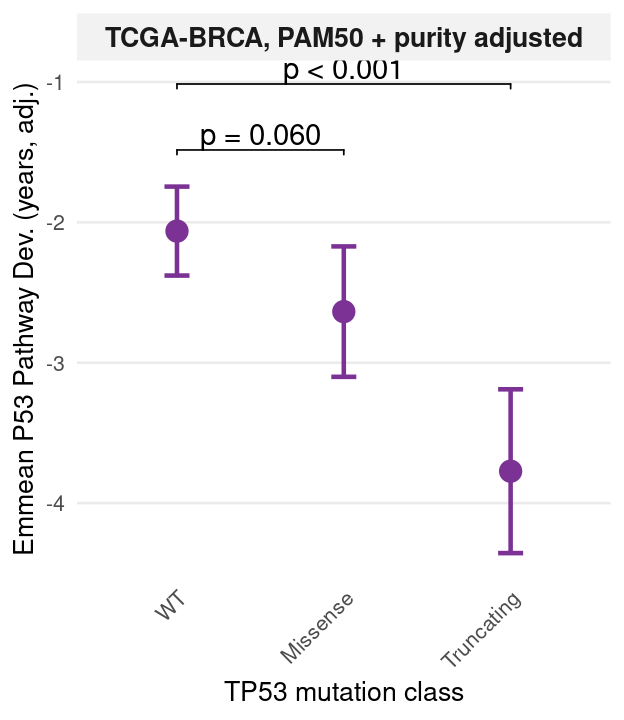

```r
tp53_levels <- c("WT", "Missense", "Truncating")
adj_label   <- "Patients with purity, purity-adjusted"

emm_plot_df <- tp53_emm_tbl %>%
  dplyr::filter(panel == adj_label) %>%
  dplyr::mutate(tp53 = factor(as.character(tp53), levels = tp53_levels),
                panel = "TCGA-BRCA, PAM50 + purity adjusted")

# significance brackets positioned above the CI tops, staggered, as in the main figure
ci_top  <- max(emm_plot_df$upper.CL)
ci_span <- max(emm_plot_df$upper.CL) - min(emm_plot_df$lower.CL)

annot_df <- tp53_tbl %>%
  dplyr::filter(panel == adj_label) %>%
  dplyr::mutate(
    tp53       = sub(" - WT$", "", contrast),
    p_label    = ifelse(p_value < 0.001, "p < 0.001", sprintf("p = %.3f", p_value)),
    y.position = ci_top + ci_span * (0.10 + 0.18 * (dplyr::row_number() - 1)),
    group1     = "WT",
    group2     = tp53,
    panel      = "TCGA-BRCA, PAM50 + purity adjusted"
  )

p_tp53 <- ggplot(emm_plot_df, aes(x = tp53, y = emmean)) +
  geom_errorbar(aes(ymin = lower.CL, ymax = upper.CL), width = 0.15, linewidth = 0.8, colour = "#7b3294") +
  geom_point(size = 3.5, colour = "#7b3294") +
  ggpubr::stat_pvalue_manual(
    annot_df,
    label       = "p_label",
    xmin        = "group1",
    xmax        = "group2",
    y.position  = "y.position",
    tip.length  = 0.01,
    inherit.aes = FALSE
  ) +
  facet_wrap(~ panel, nrow = 1) +
  labs(x = "TP53 mutation class", y = "Emmean P53 Pathway Dev. (years, adj.)") +
  theme_minimal(base_size = 10) +
  theme(
    strip.text         = element_text(size = 10, face = "bold"),
    strip.background   = element_rect(fill = "grey95", colour = NA),
    panel.grid.minor   = element_blank(),
    panel.grid.major.x = element_blank(),
    axis.text.x        = element_text(size = 8, angle = 45, hjust = 1, vjust = 1),
    axis.text.y        = element_text(size = 8)
  )

p_tp53
```

# Save outputs

When `save_outputs` is true (the default): the four panels as PDF, at the sizes of the corresponding main panels, and the survival table as CSV.

```r
if (isTRUE(params$save_outputs)) {
  tables_root_abs <- here::here(params$tables_root)
  fig_dir_abs     <- here::here(params$fig_dir)
  dir.create(tables_root_abs, recursive = TRUE, showWarnings = FALSE)
  dir.create(fig_dir_abs,     recursive = TRUE, showWarnings = FALSE)

  out_tbl <- file.path(tables_root_abs, "Supplement_purity_survival_by_cancer.csv")
  utils::write.csv(surv_purity_si_tbl, file = out_tbl, row.names = FALSE)
  msg("Saved: ", out_tbl)

  ggsave(file.path(fig_dir_abs, "Supplement_purity_deviation_vs_purity.pdf"),   p_dev_purity,  width = 8,    height = 5,    units = "in")
  ggsave(file.path(fig_dir_abs, "Supplement_purity_PAM50_deviation.pdf"),       p_subtype_adj, width = 3.5,    height = 3.5, units = "in")
  ggsave(file.path(fig_dir_abs, "Supplement_purity_OS_forest.pdf"),             p_brca_forest, width = 5,    height = 3,  units = "in")
  ggsave(file.path(fig_dir_abs, "Supplement_purity_TP53_P53phi.pdf"),           p_tp53,        width = 3.5, height = 3.5, units = "in")
  msg("Saved figures to: ", fig_dir_abs)
}
```